# INFO370 PS3

*Name*: Bridget Leonard \ *Collaborators*: 1) Saimanasvi Charugundla

```python
import numpy as np
import matplotlib.pyplot as plt
```

# Q1.Explore Central Limit Theorem

### 1.1

Random variable (RV) assigns numbers to different outcomes in a sample space. Most of these outcomes are not naturally numbers, but we need them to be to analyze them mathmatically. An example of this is flipping a coin. We can do little exploration into the two outcomes: head or tails, with those values. However, if we assign heads a value of 1, and tails a value of 0, we can now use probabilities and random variable to assess expectations for the the events. Our RV, X, is a random variable because the possible events in X's sample space are assigned values, that is -1 and 1. That is X(heads) = 1 and X(tails) = -1.

### 1.2

```python
# create a function that returns the expected value and variance based on X (RV number assignments) and their corresponding probabilities
def expect(x, p):
    expVal = 0
    for i in range(len(x)):
        expVal += x[i] * p[i]
    print("Expected Value:", expVal)
    xsqr = 0
    for i in range(len(x)):
        xsqr += ((x[i])**2 * p[i])
    var = xsqr - (expVal)**2
    print("Variance:", var)
```

```python
expect([-1, 1], [0.5,0.5])
```

```
Expected Value: 0.0
Variance: 1.0
```

Expected value is a property of the random variable, it's the expected true mean of the population. Sample mean is a property of our sample, it is the average calculated from our sample data.

### 1.3

```python
R = 1000
```

### 1.4

```python
def real(R, S):
    x = []
    for i in range(R):
        y = np.random.randint(0,2, S)*2 - 1
        x.append(np.mean(y))
    return(x)
```

```python
x = real(R, 1)
```

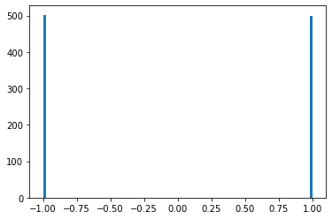

```python
_ = plt.hist(x, bins=100)
```

### 1.5

```python
np.mean(x), np.var(x)
```

```
(-0.018, 0.999676)
```

The sample mean is very close to the expected value (~.02 off) and the sample variance is even closer to the variance (<0.001 off)

### 1.6

```python
y = real(R, 2)
```

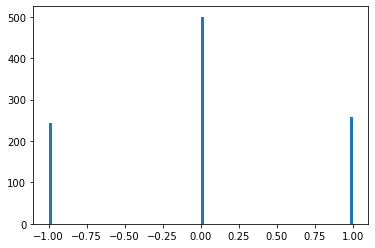

```python
_ = plt.hist(y, bins=100)
```

There are now three possible outcomes (2 tails, 1 tail/1head, or 2 heads) seen on the x axis. The middle value of 0 has a higher peak because there are two ways to get the event [-1, 1] or [1, -1] to get the pair mean of 0.

### 1.7

```python
np.mean(y), np.var(y)
```

```
(-0.017, 0.46671099999999993)
```

### 1.8

```python
expect([-1, 0, 1], [0.25, 0.5, 0.25])
```

```
Expected Value: 0.0
Variance: 0.5
```

This matches what we would predict given the CLT, that is the variance of the pair mean is half (0.5) of our S = 1 variance we got in question 1.2 (1).

### 1.9

```python
# Merge the functions created so far to make a function that gives expected value/variance, sample mean and variance, and also a histogram
def sample(R, S):
    x = []
    for i in range(R):
        y = np.random.randint(0,2, S)*2 - 1
        x.append(np.mean(y))
    print("Sample mean:", np.mean(x))
    print("Sample variance:", np.var(x))
    _ = plt.hist(x, bins=100)

# add s, sample size parameter, to calculate variance and add default arguments
def expect(s, x=[-1,1], p=[0.5,0.5]):
    expVal = 0
    for i in range(len(x)):
        expVal += x[i] * p[i]
    print("Expected Value:", expVal)
    xsqr = 0
    for i in range(len(x)):
        xsqr += ((x[i])**2 * p[i])
    var = (xsqr - (expVal)**2) / s
    print("Variance:", var)
```

```
Sample mean: 0.0092
Sample variance: 0.18839536000000004
```

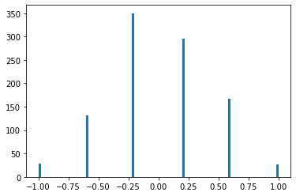

```python
sample(R, 5)
```

```python
expect(5)
```

```
Expected Value: 0.0
Variance: 0.2
```

Our theoretical and sample versions of mean and variance are very close. Sample mean is about .01 off from the expected value, while sample variance is also about .01 off from the expected variance.

The biggest difference in the histogram is that there are now 6 outcomes for our sample which results in 6 different possible means for each 5-tuples of random numbers. This also is created a more normal distribution.

### 1.10

```
Sample mean: 0.013120000000000001
Sample variance: 0.0415942656
```

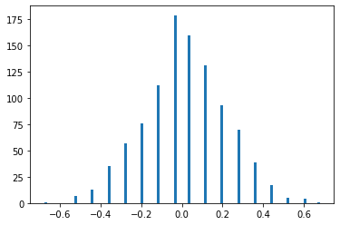

```python
sample(R, 25)
```

```python
expect(25)
```

```
Expected Value: 0.0
Variance: 0.04
```

The sample values are getting closer to the expected values. The sample mean is still about 0.01 off from the expected value, but the sample variance is now only 0.001 off from the theoretical variance.

### 1.11

```
Sample mean: -0.00095
Sample variance: 0.0010138215000000002
```

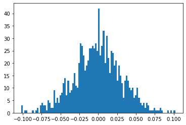

```python
sample(R, 1000)
```

```python
expect(1000)
```

```
Expected Value: 0.0
Variance: 0.001
```

### 1.13

As S grows (approaches infinity), the sum of independent random variables (i.e., 1000 different coins) tends to be normally distributed. This is the main idea of the Central Limit Theorem. Specifically, as sample size grows, the sample mean gets closer and closer to the expected value. When we go to one sample (S = 1) to two (S = 2), we are introducing more random variables for each sample space; instead of just getting heads or tails (-1 or 1), we can now get HH, HT, TH, or TT averaging to either -1, 0, or 1. Each time we add a sample, we grow the outcomes to S + 1 because we can get 0 to S heads in each tuple.

### 1.14

S is the sample size. R is the number of repetitions. S refers to the number of independent random variables we are using in each repetition of the data collection. S impacts the distribution along the x axis of the histogram. As S gets larger, new possible sample means are introduced which adds new "columns" to the histogram and creates a normal curve as it approaches infinity. R impacts the distribution along the y axis. As it increases, we obtain samples that are more closely reflective of the probabilities of obtaining those events. For example if R is small, chance has a stronger influence in the sample and we may obtain 3 single-sample values of all heads. As R grows, more tail values will appear and even out the distribution to be more 50/50 (in a S = 1 sample).

# Q2.Is poverty in Azraq refugee camp falling?

### 2.1

```python
p1 = 0.66
p2 = 0.51
```

```python
s = 325
```

### 2.2

#### 2.2.1

```python
def bin(p, size):
    return np.random.binomial(1,p, size)
```

```python
x1 = bin(p2, s)
```

#### 2.2.2

```python
np.mean(x1)
```

```
0.48307692307692307
```

The sample mean is close to p2, but much less than p1.

#### 2.2.3

```python
R = 10000
```

#### 2.2.4

```python
def binSamp(p, size, R):
    x = []
    for i in range(R):
        y = np.random.binomial(1,p, size)
        x.append(np.mean(y))
    return x
```

```python
x2 = binSamp(p2, s, R)
```

#### 2.2.5

```python
np.mean(x2)
```

```
0.5100058461538461
```

The average of R averages is closer to p2 than to p1.

#### 2.2.6

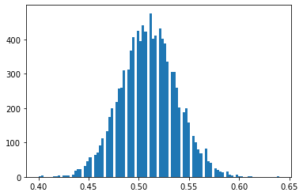

```python
_ = plt.hist(x2, bins=100)
```

The histogram of average resembles a normal distribution. It seems like smallest reasonable common value is around 0.46 and the largest reasonably common value is around 0.55

#### 2.2.7

```python
np.percentile(x2, [2.5, 97.5])
```

```
array([0.45538462, 0.56615385])
```

### 2.3

#### 2.3.1

```python
varX = 0.51 * (1 - 0.51)
varX
```

```
0.2499
```

```python
np.var(x1)
```

```
0.24971360946745558
```

#### 2.3.2

The CLT tells us that the variance of the sample mean is the sample variance divided by the sample size

#### 2.3.3

```python
sigma = varX / s
sigma
```

```
0.000768923076923077
```

#### 2.3.4

```python
np.var(x2)
```

```
0.0007850844628639053
```

The standard deviation of the sample of averages (x2) is very similar to the standard deviation of sample mean.

#### 2.3.5

```python
std = np.sqrt(sigma)
lower = p2 - (std * 2)
upper = p2 + (std * 2)
lower, upper
```

```
(0.4545410754910239, 0.5654589245089761)
```

# Time Spent

I spent about 4 hours on this problem set

## 2.4 Challenge

#### 2.4.1

```python
%timeit for i in range(10): binSamp(p2, s, R)
```

```
3.1 s ± 376 ms per loop (mean ± std. dev. of 7 runs, 1 loop each)
```

```python
%timeit for i in range(5): binSamp(p2, s, R)
```

```
1.3 s ± 117 ms per loop (mean ± std. dev. of 7 runs, 1 loop each)
```

```python
%timeit for i in range(15): binSamp(p2, s, R)
```

```
3.73 s ± 150 ms per loop (mean ± std. dev. of 7 runs, 1 loop each)
```

```python
%timeit for i in range(20): binSamp(p2, s, R)
```

```
4.98 s ± 127 ms per loop (mean ± std. dev. of 7 runs, 1 loop each)
```

```python
sec = 100000000000 * 3
sec
```

```
300000000000
```

```python
minute = sec / 60
minute
```

```
5000000000.0
```

```python
hr = minute / 60
hr
```

```
83333333.33333333
```

```python
day = hr / 24
day
```

```
3472222.222222222
```

```python
year = day / 365
year
```

```
9512.937595129375
```

To run 10^12 simulations it would take about 9.5 thousand years/9.5 millenia.

#### 2.4.2

```python
p1, p2, std
```

```
(0.66, 0.51, 0.02772946225448804)
```

```python
t = (p2 - p1) / std
t
```

```
-5.409408903186443
```

#### 2.4.3

```python
from scipy import stats
```

```python
norm = stats.norm()
```

```python
norm.cdf(-1.96)
```

```
0.024997895148220435
```

```python
p = norm.cdf(t)
p
```

```
3.161655253291475e-08
```

To calculate t values, we subtract the mu of the null hypothesis (in this case, p1) from the sample mu (in this case, p2). Since mu0 is larger than the sample mu, we get a negative numerator, and thus, a negative t-value.

#### 2.4.4

```python
i = 3/p
i
```

```
94887005.68718927
```

We need about 95,000,000 iterations.

```python
sec = (i/10) * 3
sec
```

```
28466101.706156783
```

```python
minute = sec / 60
minute
```

```
474435.0284359464
```

```python
hr = minute / 60
hr
```

```
7907.2504739324395
```

```python
day = hr / 24
day
```

```
329.468769747185
```

```python
year = day / 365
year
```

```
0.9026541636909178
```

It would take almost one year to run all the iterations needed to get a value as extreme as p1. It could not be completed by the assignment deadline but doable for all other measures of time.